# Seaborn for Visualizations

### Facetgrid, Layer Single Plot

Facetgrid allows multiple plots like small-multiples, trellis, lattice graphs of different plots (line, bar, scatter)

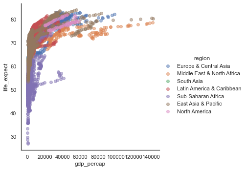

```python
# Example from QMB 6930
# FacetGrid to color the scatterplot by regions
sns.FacetGrid(nations, hue="region", size=5) \
.map(plt.scatter, "gdp_percap", "life_expect", alpha = 0.5) \
.add_legend()

sns.despine()
```

### Matrix Multiples

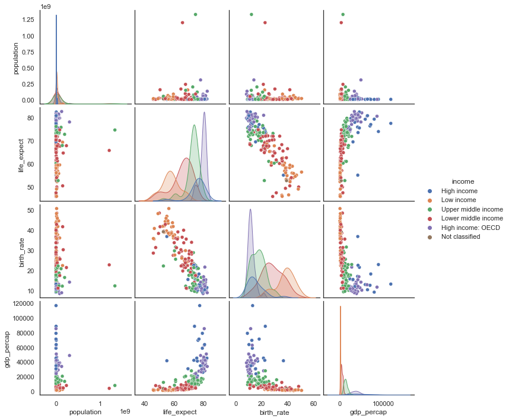

```python
sns.pairplot(
    nations[nations.year == 2008][[
        'income', 'population', 'life_expect', 'birth_rate', 'gdp_percap'
    ]].dropna(),
    hue='income'
)

sns.despine()
```

## Strip Plots

#Strip Plots draws values on a number line to visualize samples of a single variable import pandas as pd import matplotlib.pyplot as plt import seaborn as sns #load the dataset variable = sns.load_dataset('nameoffile') sns.stripplot(y='columnname', data=variable) plt.ylabel('Label') plt.show() #You can draw parrell strip plots for each variable in x import pandas as pd import matplotlib.pyplot as plt import seaborn as sns #load the dataset variable = sns.load_dataset('nameoffile') sns.stripplot(x='columnname', y ='columnnameb', data=variable) plt.ylabel('Label') plt.show() #In a strip plot repeated values are drawn ontop of each other. #To show repeated values you can add the arguments size= and jitter=True or use a swarm plot. import pandas as pd import matplotlib.pyplot as plt import seaborn as sns #load the dataset variable = sns.load_dataset('nameoffile') sns.stripplot(x='columnname', y='columnnameb', data=variable, size=4, jitter=True) plt.ylabel('Label') plt.show()

## Violin Plots

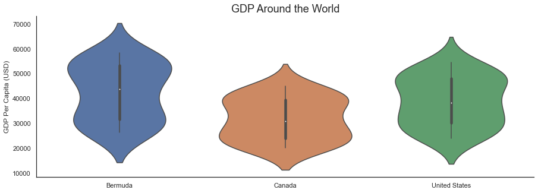

```python
# Denser regions of the data are fatter, and sparser thiner in a violin plot
sns.violinplot(x="country", y="gdp_percap", data= nations[nations.region == "North America"], size=6)

plt.title("GDP Around the World", size=18)
plt.ylabel("GDP Per Capita (USD)")
plt.xlabel("")

sns.despine()
```

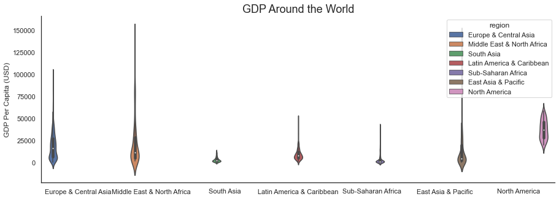

```python
#Use rc={'figure.figsize': to specify chart sizes, in this case making it wider

sns.set(
    rc={'figure.figsize':(15,5)},
    style="white"
)
sns.violinplot(
    x='region',
    y='gdp_percap',
    hue='region',
    data=nations
)

plt.title("GDP Around the World", size=18)
plt.ylabel("GDP Per Capita (USD)")
plt.xlabel("")

sns.despine()
```

#Takes forever to load g = sns.catplot(x='life_expect', y='gdp_percap',hue='region', row="income", data=nations, orient="h", palette="Set3", kind="violin", dodge=True, cut=0, bw=.2)

## Appendix 1: Summary of Arguments

### sns.despine()

seaborn.despine(fig=None, ax=None, top=True, right=True, left=False, bottom=False, offset=None, trim=False) Remove the top and right spines from plot(s).

### sns.set()

seaborn.set_theme(context='notebook', style='darkgrid', palette='deep', font='sans-serif', font_scale=1, color_codes=True, rc=None)

## Appendix 2: Colors

- **color_palette():** define a color map that you want to be using and the number of colors with the argument n_colors (Willems 2017). Documentation: https://seaborn.pydata.org/generated/seaborn.color_palette.html Seaborn Tutorial: https://seaborn.pydata.org/tutorial/color_palettes.html#palette-tutorial

```python
#Sets the color for all your graphs
sns.set_palette("tab10")
```

```python
sns.color_palette()
```

[output not shown]

```python
sns.color_palette(n_colors=5)
```

[output not shown]

```python
#Desaturate colors by specifing a float to desat=
sns.color_palette(n_colors=5, desat=.33)
```

[output not shown]

```python
sns.color_palette(palette='colorblind')
```

[output not shown]

```python
sns.color_palette("flare")
```

[output not shown]

```python
#Reverse order
sns.color_palette("flare_r")
```

[output not shown]

```python
sns.color_palette("coolwarm", n_colors=10)
```

[output not shown]

```python
sns.color_palette('vlag', n_colors=10)
```

[output not shown]

### Appendix 3: Combining Plots

sns.violinplot(x='columnname', y='columnnameb', data=variable, inner=None, color='lightgray') sns.stripplot(x='columnname', y='columnnameb', data=variable, size=4, jitter=True) plt.ylabel('Label') plt.xlabel('Label') Plt.show()

## References

Formated in APA with the authors name on it's own line in order to hyperlink in document. Then bullet points below on what I found particularly useful.

Lastname, F. M. (Year, Month Date). *Title of page.* Site name. URL

##### Bosler, F.

(2019, October 20). *Learn how to create beautiful and insightful charts with Python — the Quick, the Pretty, and the Awesome.* Median, Towards Data Science. https://towardsdatascience.com/plotting-with-python-c2561b8c0f1f

- Great examples of facet grids and the matrix small multiples.

##### Willems, K.

(2017, August 10) *Python Seaborn Tutorial For Beginners*. DataCamp Tutorials. https://www.datacamp.com/community/tutorials/seaborn-python-tutorial#xlim